# Case Study: Triaging GitHub Issues with Generative AI & Vector DB

## 1. What is GitHub/Issue?

**GitHub** is the most popular platform/cloud-based service where software developers contribute to the open source community. GitHub provides version control, using **Git** tool, that software developers use to create, store and track/control changes to the software artifacts in their repositories.

**GitHub** users use **issues** to report bugs, propose new features, request documentation updates, and track change requests/status for repositories published on GitHub.

## 2. What is the Problem?

There are three problems that we want to tackle in this case study:

1. **Triaging the GitHub Issues:** A significant number of **GitHub issues** that are created by GitHub users do NOT have **labels**; using labels and tags is the most common way to triage change requests/issues and be submitted for review by the moderator/owner/contributor of the repo to accept/reject/postpone the issue.
2. **Sanitizing the GitHub Issues:** There are a few **GitHub issues** that are created by GitHub users that are general questions and should be asked on **StackOverflow** or **Community Forums**, for example, (https://community.openai.com/) or (https://www.reddit.com/r/OpenAI/). General questions should be removed from the list of issues to be considered for review by the moderator/owner/contributors of the repo.
3. **Duplicate Bugs/Issues:** Detection of duplicate bugs is an area that was studied extensively over the years in the area of **Automated Software Engineering**. Public repositories on GitHub are used by users that often have little or no coordination when they report the bugs/issues they encounter, hence a significant number of reported bugs/issues for a certain repository will have a high probability to be tagged as a duplicate bug/issue. These duplicate bugs/issues need to be detected.

## 3. What is the Solution?

Our solution to address these problems will:

1. Utilize **OpenAI gpt-3.5-turbo** and **text-embedding-ada-002 models** to create embeddings for the issues and categorize the repository issues.
2. Use **Milvus Vector DB** for semantic search and filtered search (**Hybrid Search** is vector search with attribute filtering).

### Learning Objectives:

- Create **Word Embeddings** for documents
- Create a **Vector Database** application
- Use **Generative AI models** for similarity/relatedness search
- Utilize Vector Embeddings and Scalar Field Filters to perform **Hybrid Search** queries

### Learning Outcomes:

- **Build a Vector Database** for the data of a real-world case study, GitHub Repos/Issues
- **Deploy Generative AI models** to triage, sanitize, and detect duplicate text in the data of a real-world case study, GitHub Repos/Issues
- **Leverage the power of Prompt Engineering and Hybrid Search** to improve the retrieval accuracy for the results of queries exercised on the data of a real-world case study, GitHub Repos/Issues

### Deliverables:

- Use Panopto to create MP4 Video Recording of your live Demo
- The IPYNB script that you created and used for development and testing
- Use 7-Zip to create a file with the name "YourLastName_Triaging_GitHub_Issue" that has the IPYNB you created and your MP4 Panopto Video Recording
- It is required that you provide your code and output inline below every requirement for this Assignment

## Your Workflow for this Script:

1. Download/Install Required Tools/Packages
2. Create your OpenAI and GitHub Accounts/API-Keys
3. Collect Repo Issues from GitHub
4. Use OpenAI **text-embedding-ada-002** Model to create embeddings for the GitHub Issues
5. Create a Collection for GitHub Issues/Embeddings in Milvus Vector DB
6. Insert every Issue and its Embedding into Milvus Vector DB
7. Execute different queries using Milvus Vector DB
8. Use OpenAI **gpt-3.5-turbo** Model to get a listing of top 3 categories for the GitHub Issues for every repo
9. Create your analysis/synthesis for the results produced and how you will triage every issue you collected from GitHub for every Repo

## Tools & Packages you need to download:

- Docker
- Mlivus DB
- Attu
- pymilvus
- OpenAI

*Steps, links, and tutorials to download and install these tools/packages are provided later in this script*

## Accounts/API Keys you need to create

- GitHub API Account and Key
- OpenAI API Account and Key

*Steps, links, and tutorials to create these accounts/api-keys are provided later in this script*

### Since there is a potential of large amount of data fetched from GitHub Repos/Issues, startup your jupyter notebook by executing the following command from anaconda terminal, as follows:

- jupyter notebook --NotebookApp.iopub_data_rate_limit=10000000

## References

**Note:** To access **IEEE** and **ACM** papers, please use your school ID to access the school's library portal which will give you free access to IEEE and ACM digital libraries.

- Yang, X et al. 2016. Combining Word Embedding with Information Retrieval to Recommend Similar Bug Reports, IEEE International Symposium on Software Reliability Engineering (ISSRE).
- Klein, N. et al. 2014. New features for duplicate bug detection. In Mining Software Repositories. ACM.
- Runeson, P. et al.2007. Detection of Duplicate Defect Reports Using Natural Language Processing, International Conference on Software Engineering (ICSE).
- ALazar, A. et al. 2014. Generating duplicate bug datasets. In Mining Software Repositories. ACM.
- Nguyen, A. et al. 2012. Duplicate Bug Report Detection With a Combination of Information Retrieval and Topic Modeling, IEEE/ACM International Conference on Automated Software Engineering (ASE),
- Bug Triage Process: https://www.browserstack.com/guide/bug-triage-process
- Milvus: https://milvus.io/
- OpenAI API: https://platform.openai.com/docs/api-reference?lang=python
- Prompt Engineering: https://platform.openai.com/docs/guides/prompt-engineering
- OpenAI and Milvus Cookbook: https://github.com/openai/openai-cookbook/blob/main/examples/vector_databases/milvus/Filtered_search_with_Milvus_and_OpenAI.ipynb
- GitHub Labels: https://docs.github.com/en/issues/using-labels-and-milestones-to-track-work/managing-labels
- StackOverflow Tags:
  - https://stackoverflow.com/help/tagging
  - https://stackoverflow.com/tags
  - https://stackoverflow.blog/2010/08/01/tag-folksonomy-and-tag-synonyms
  - https://stackoverflow.com/help/tag-excerpts

# Tools/Packages Installation & Accounts/API-KEYs Setup

# GitHub

- Create your Developer Account on GitHub
- On the left panel in your Developer Account (https://github.com/settings/profile) scroll down select Developer Settings
- Create your GitHub API Key Under Developer Setting (https://github.com/settings/tokens). Select Personal access tokens (classic)
- Click the upper right corner button "Generate new token"

[figure not shown]

# Docker

### Docker 101 Tutorial

Before you start the download/installation of Docker Desktop, watch the **Docker Crash Course for Absolute Beginners** video below.

```python
from IPython.display import YouTubeVideo

YouTubeVideo('pg19Z8LL06w', width=600, height=350)
```

[video not shown]

## Install Docker Desktop from here: https://docs.docker.com/engine/install/

[figure not shown]

### Architectural View of Docker/Containers

- Source: https://docs.docker.com/get-started/overview/

[figure not shown]

```python
! docker-compose up -d
```

```
WARN[0000] /Users/jung/Projects/Python/msds-420/Assignment_7/docker-compose.yaml: the attribute `version` is obsolete, it will be ignored, please remove it to avoid potential confusion
[+] Running 4/4
 ✔ Container milvus-etcd        Running                                    0.0s
 ✔ Container milvus-minio       Running                                    0.0s
 ✔ Container milvus-standalone  Running                                    0.0s
 ✔ Container attu               Running                                    0.0s
```

## Note: Make sure Docker Daemon is running, if not, you can start it up by running Docker Desktop

- Type the following command to verify from the command prompt
  - docker ps

# OpenAI

### OpenAI API 101 Tutorial

Before you create your OpenAI API developer Account/API-Key, watch the **Getting Started With OpenAI ChatGPT (GPT-3.5) API In Python** video below.

```python
from IPython.display import YouTubeVideo

YouTubeVideo('I4T--ycOpi0', width=600, height=350)
```

[video not shown]

### Create your OpenAI API developer account and API-Key

- Create your Developer Account on OpenAI (https://platform.openai.com/docs/quickstart?context=python)
- Click on create OpenAI account link
- After you login, hoover the mouse over the OpenAI logo (Upper Left Corner).
- Click API keys
- Click Create new secret key Button

### Please make sure you check regularly on your usage of OpenAI API when using GPT-3.5 Turbo and Embedding models

- After you login to OpenAI, hoover the mouse over the OpenAI logo (Upper Left Corner).
- Click Usage

[figure not shown]

# Milvus

### Milvus 101 Tutorial

Before you start the download/installation of Milvus, watch the **Milvus vector database in 150 Seconds** video below.

```python
from IPython.display import YouTubeVideo

YouTubeVideo('nQkmgCtVz5k', width=600, height=350)
```

[video not shown]

### Download/Install Milvus Standalone using Docker Compose

- Create a subdirectory **"C:\Workbench\milvus"**
- Download **milvus-standalone-docker-compose.yml** and save it as **docker-compose.yml** in directory **"C:\Workbench\milvus"**
  - https://milvus.io/docs/install_standalone-docker.md
  - https://github.com/milvus-io/milvus/releases/download/v2.3.3/milvus-standalone-docker-compose.yml

[figure not shown]

- From the directory "C:\Workbench\milvus" that has the file **docker-compose.yml**, execute the following command from the terminal:
  - docker compose up -d

[figure not shown]

### Verify Milvus services started by entering 'docker ps' from the terminal:

[figure not shown]

Since we intend to interact with Milvus Vector database instance using Python, we need two more items:

- pymilvus package (https://pymilvus.readthedocs.io/en/latest/tutorial.html), we use pip install pymilvus
- Attu tool to verify data inserted into our Collection on PM server, you can download Attu from this URL (https://milvus.io/docs/v2.0.x/attu_install-package.md)

[figure not shown]

## Vector Similarity Search for Milvus :

In Milvus, the **vector similarity search** calculates the distance between the query vector and vectors representing the data/text/document in the collection with the provided similarity metrics, and it will return the most similar results. In this script, we will represent every GitHub issue by a vector.

In Milvus, we can perform a hybrid search by specifying a boolean expression that filters the scalar field or the primary key field, for example filter issues that have created_at date 2023-12-15.

- Milvus API is documented in detailed here: https://milvus.io/docs/search.md
- A vector similarity search in Milvus calculates the distance between query vector(s) and vectors in the collection with specified similarity metrics, and returns the most similar results. You can perform a hybrid search by specifying a boolean expression that filters the scalar field or the primary key field.

## Similarity Metrics for Milvus

In Milvus, similarity metrics are used to measure similarities among vectors.

- The API is documented in detailed here: https://milvus.io/docs/metric.md
- In this script, we are using Euclidean distance (L2) similarity metric provided by Milvus
- You could do 5-minutes reading about Euclidean distance (L2) similarity metric here: https://en.wikipedia.org/wiki/Euclidean_distance
  - Deriving the n-dimensional Euclidean distance formula by repeatedly applying the Pythagorean theorem
  - The source of the following images for the equation and figure is Wikipedia: https://en.wikipedia.org/wiki/Euclidean_distance

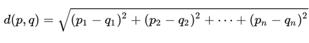

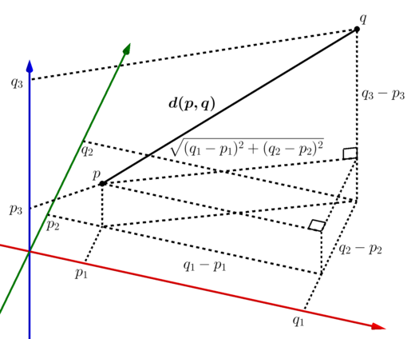

# Attu

### Vector database admin tool

**Attu** is an admin tool that we will use to check if our vector database collection is create and check if vectors inserted into the database collection.

Download **Attu** Release v2.3.5 from the following URL:

- https://zilliz.com/attu
- https://github.com/zilliztech/attu/releases/

[figure not shown]

# Install Required Python Packages

```python
! pip install openai pymilvus tqdm python-dotenv
```

### Now that we have finished the download/installation of the needed tools/packages and the setup of the Accounts/API-Keys, lets start our instrumentation and coding

```python
import requests
import datetime
import time
import os
import openai
import json

from datetime import date
from pymilvus import connections, utility, FieldSchema, Collection, CollectionSchema, DataType
```

# Enter your API KEYS

*Remove your api-keys once you are done working on this script*  
*Try to use to use os.getenv(...) instead of hard-coding your API-Keys in the script*

- openai.api_key = os.getenv('OPENAI_API_KEY')
- github_api_key = os.getenv('GITHUB_API_KEY')

```python
import os
from dotenv import load_dotenv

# Load environment variables from .env file
load_dotenv()

# Now use them
headers = {
    "Accept": "application/vnd.github+json",
    "Authorization": f"Bearer {os.environ.get('GITHUB_TOKEN')}",
    "X-GitHub-Api-Version": "2022-11-28"
}

github_username = os.environ.get('GITHUB_USERNAME')

# Check if credentials are loaded
print(f"GitHub Username: {github_username}")
print(f"GitHub Token loaded: {'Yes' if os.environ.get('GITHUB_TOKEN') else 'No'}")
```

```
GitHub Username: jsuh-911
GitHub Token loaded: Yes
```

```python
# Get the API key
openai_api_key = os.environ.get('OPENAI_API_KEY')
```

```python
# Please don't alter the following settings.

# After you learn how Milvus uses OpenAI 'text-embedding-ada-002' Model to create Vector-Embedding,
# you can change the setting


HOST = 'localhost'
PORT = 19530
COLLECTION_NAME = 'GitHub_Repo_Issues'
DIMENSION = 1536

OPENAI_ENGINE = 'text-embedding-ada-002'
GPT_MODEL = "gpt-3.5-turbo"


INDEX_PARAM = {
    'metric_type':'L2',
    'index_type':"HNSW",
    'params':{'M': 8, 'efConstruction': 64}
}

QUERY_PARAM = {
    "metric_type": "L2",
    "params": {"ef": 64},
}

BATCH_SIZE = 1000
```

# Collect Repo/Issues from GitHub

```python
# Define a dictionary of owners and their repositories
dict_of_owners_and_repositories = {
    'openai':['openai-cookbook'],
    'docker': ['compose'],
    'keras-team': ['keras'],
    'facebook': ['react']
}
```

```python
def create_github_url(owner, repo):
    # Don't embed credentials in URL - use headers for authentication
    return f"https://api.github.com/repos/{owner}/{repo}/issues"
```

Make a note of the following:

- While you are doing UNIT-TESTING limit the time-window to 7 days only; you could change than to longer period when you are done with your unit-testing.
- OpenAI charges are based on how many tokens it used for your text embeddings
- Sending hundreds of thousands of issues for OpenAI might result in high charges.
- Instrumentation and Experimental results IN this script demonstrated that charges from OpenAI didn't exceed $1 even when creating embeddings for 1500 issues for every run of the multiple runs that got executed

```python
#defining per page value and from date to specify the of data to fetch from GitHub

page = 1
per_page = 2

#defining since date

from_date = (date.today() - datetime.timedelta(days=10)).isoformat()

print(from_date)
```

```
2025-08-07
```

```python
# Global object to store all issues retrieved/fetched from GitHub for our list of Repos we are interested in
# List of all issues fetched for our list of Repos we are interested in

list_of_all_issues_fetched = []
```

```python
def fetch_repo_issues(owner, repo, page, per_page, from_date):
    github_url = create_github_url(owner, repo)
    current_time = time.time()

    while True:
        # Fix 1: Remove duplicate '/issues' since create_github_url already includes it
        response = requests.get(github_url, headers=headers, params={
            "since": from_date,
            "page": page,
            "per_page": per_page,  # Add per_page parameter
            "state": "all"
        })

        # Fix 2: Check response status first
        if not response.ok:
            print(f"❌ Error {response.status_code} for {owner}/{repo}: {response.text}")
            break

        try:
            issues = response.json()

            # Fix 3: Check if response is a list (issues) or dict (error)
            if isinstance(issues, dict):
                if 'message' in issues:
                    print(f"❌ API Error for {owner}/{repo}: {issues['message']}")
                    break
                else:
                    print(f"❌ Unexpected response format for {owner}/{repo}")
                    break

            # Fix 4: Print sample only once, not for every issue
            if page == 1 and len(issues) > 0:
                print(f"Sample response for {owner}/{repo}:")
                print(f"First issue keys: {list(issues[0].keys()) if issues else 'No issues'}")

            # Fix 5: Process each issue safely
            for issue in issues:
                if isinstance(issue, dict):  # Ensure issue is a dictionary
                    list_of_all_issues_fetched.append({
                        'repo_name': repo,
                        'owner': owner,
                        'number': issue.get('number'),
                        'created_at': issue.get('created_at'),
                        'updated_at': issue.get('updated_at'),
                        'title': issue.get('title', ''),
                        'body': issue.get('body', ''),
                        'repository_url': issue.get('repository_url', '')
                    })
                else:
                    print(f"⚠️ Issue is not a dictionary: {type(issue)}")

            print(f"✅ Fetched {len(issues)} issues from {owner}/{repo} (page {page})")

            # Fix 6: Stop if no more issues
            if len(issues) == 0:
                break

        except ValueError as e:
            print(f"❌ JSON decode error for {owner}/{repo}: {e}")
            print(f"Response text: {response.text[:200]}...")
            break
        except Exception as e:
            print(f"❌ Unexpected error for {owner}/{repo}: {e}")
            break

        page += 1
        time.sleep(1)  # Add rate limiting

    print(f"Total issues fetched for repo {repo}: {len([i for i in list_of_all_issues_fetched if i['repo_name'] == repo])}")
    print(f"Time spent to fetch {repo} issues: {round(time.time() - current_time, 2)} seconds\n")
```

### Please allow 2 minutes for the following to complete fectching data from GitHub for the repos listed above

```python
# Fetch all issues for every repo in our list of Repos we are interested in from GitHub

for owner, repos in dict_of_owners_and_repositories.items():
    for repo in repos:
        fetch_repo_issues(owner, repo, page, per_page, from_date)
```

[output not shown]

[output cut: 170 more lines]

[output not shown]

```python
list_of_all_issues_fetched
```

[output not shown]

[output cut: 3169 more lines]

[output not shown]

```python
#Random sample from issues stored

list_of_all_issues_fetched[0]
```

```
{'repo_name': 'openai-cookbook',
 'owner': 'openai',
 'number': 2068,
 'created_at': '2025-08-16T20:40:15Z',
 'updated_at': '2025-08-16T20:50:10Z',
 'title': '[PROBLEM] Blank response from transformer serve using openai/gpt-oss-20b',
 'body': '**Describe the problem**\n1. Follow https://github.com/openai/openai-cookbook/blob/main/articles/gpt-oss/run-transformers.md \n2. clone openai/gpt-oss-20b\n3. With Python 3.10.* create a venv\n4. `pip install transformers torch Pillow transformers[serving] rich aiohttp`\n5. run `transforme…
 'repository_url': 'https://api.github.com/repos/openai/openai-cookbook'}
```

```python
#Random sample from issues stored

list_of_all_issues_fetched[1]
```

```
{'repo_name': 'openai-cookbook',
 'owner': 'openai',
 'number': 2067,
 'created_at': '2025-08-15T23:28:52Z',
 'updated_at': '2025-08-15T23:49:03Z',
 'title': 'Update openai-harmony.md',
 'body': '## Summary\r\n\r\nPorting some fixes from github.com/openai/harmony docs',
 'repository_url': 'https://api.github.com/repos/openai/openai-cookbook'}
```

```python
#Random sample from issues stored

list_of_all_issues_fetched[23]
```

```
{'repo_name': 'openai-cookbook',
 'owner': 'openai',
 'number': 2045,
 'created_at': '2025-08-11T21:51:23Z',
 'updated_at': '2025-08-11T21:52:35Z',
 'title': 'openai-harmony: remove unnecessary line from basic system prompt',
 'body': 'Remove unnecessary tool calling invitations from the basic system message.\r\n\r\n## Summary\r\n\r\nBriefly describe the changes and the goal of this PR. Make sure the PR title summarizes the changes effectively.\r\n\r\n## Motivation\r\n\r\nWhy are these changes necessary? How do they impr…
 'repository_url': 'https://api.github.com/repos/openai/openai-cookbook'}
```

```python
# Helper Function

def convert_datetime_to_unix_time(datetime_obj):
    date_format = datetime.datetime.strptime(datetime_obj, "%Y-%m-%dT%H:%M:%SZ")
    unix_time = datetime.datetime.timestamp(date_format)

    return int(unix_time)
```

```python
# Helper Function

def convert_unix_time_to_datetime(unix_time):
    datetime_obj = datetime.datetime.fromtimestamp(unix_time)
    return datetime_obj
```

```python
# Milvus as of the current release has NO SUPPORT for datetime as a datatype.
# They plan to support Postgres Datetime formatting in future releases

# So, the alternative for us, at least for now, is to convert Datetime into Unix Time
# which can be stored as an integer in Milvus and we can convert it to datetime when needed

# Run the following to familiarize yourself with datetime and unix time conversion/formatting

unix_time = convert_datetime_to_unix_time("2023-12-17T00:00:00Z")

datetime_obj = convert_unix_time_to_datetime(unix_time)

print("UNIX Time > " , unix_time)
print("Date Time > " , datetime_obj.strftime('%Y-%m-%dT%H:%M:%SZ'))
```

```
UNIX Time >  1702800000
Date Time >  2023-12-17T00:00:00Z
```

# Milvus

```python
# Connect to Milvus Database
connections.connect(host=HOST, port=PORT)
```

```python
# Remove collection if it already exists
if utility.has_collection(COLLECTION_NAME):
    utility.drop_collection(COLLECTION_NAME)
```

```python
# Create collection which includes the id, title, and embedding.
fields = [
    FieldSchema(name='id', dtype=DataType.INT64, is_primary=True, auto_id=True),
    FieldSchema(name='repo_name', dtype=DataType.VARCHAR, max_length=64000),
    FieldSchema(name='number', dtype=DataType.INT64),
    FieldSchema(name='created_at', dtype=DataType.INT64),
    FieldSchema(name='updated_at', dtype=DataType.INT64),
    FieldSchema(name='title', dtype=DataType.VARCHAR, max_length=64000),
    FieldSchema(name='body', dtype=DataType.VARCHAR, max_length=64000),
    FieldSchema(name='repository_url', dtype=DataType.VARCHAR, max_length=64000),
    FieldSchema(name='fully_qualified_issue', dtype=DataType.VARCHAR, max_length=64000),
    FieldSchema(name='embedding', dtype=DataType.FLOAT_VECTOR, dim=DIMENSION)
]

schema = CollectionSchema(fields=fields)
collection = Collection(name=COLLECTION_NAME, schema=schema)
```

```python
# Create the index on the collection and load it.
collection.create_index(field_name="embedding", index_params=INDEX_PARAM)
collection.load()
```

```python
from openai import OpenAI
client = OpenAI()
```

```python
# Simple function that converts the texts to embeddings
def embed(texts):

    embeddings = client.embeddings.create(
        input=texts,
        model=OPENAI_ENGINE
    )

    return [x.embedding for x in embeddings.data]
```

## Important Note:

- The 'text-embedding-ada-002' model's maximum context length is 8191 tokens
- If you need larger context, please see this thread/example
  - (https://github.com/openai/openai-cookbook/blob/main/examples/Embedding_long_inputs.ipynb )
- For a discussion related to this limitation, please read this thread
  - (https://community.openai.com/t/embedding-model-token-limit-exceeding-limit-while-using-batch-requests/316546)
- Average token size is 4 letters
- Since developers/users have the tendency to copy/paste code+error for the body of the issue and the body might spane multiple pages of primarily source code. So, you could limit the size of the text to be encode/vectorized to "title and repo_name" , or "title and body"; different fields could be used for this project instrumentaiton/demonstration.

```python
from tqdm import tqdm

data = [
    [], # repo_name
    [], # number
    [], # created_at
    [], # updated_at
    [], # title
    [], # body
    [], # repository_url
    [], # Concatenated fields for embeddings, for example, repo_name+title
]



# Embed and insert in batches
for i in tqdm(range(0, len(list_of_all_issues_fetched))):
    data[0].append(list_of_all_issues_fetched[i]['repo_name'] or '')
    data[1].append(list_of_all_issues_fetched[i]['number'] or -1)

    data[2].append(convert_datetime_to_unix_time(list_of_all_issues_fetched[i]['created_at']) or -1)
    data[3].append(convert_datetime_to_unix_time(list_of_all_issues_fetched[i]['updated_at']) or -1)

    data[4].append(list_of_all_issues_fetched[i]['title'] or '')
    data[5].append(list_of_all_issues_fetched[i]['body'] or '')
    data[6].append(list_of_all_issues_fetched[i]['repository_url'] or '')


    # This field is used to create the embeddings for the issues
    # We are creating and embedding for the string composed of (repo_name+repository_url+title)

    data[7].append(str(data[0][-1]) + ":: " + str(data[6][-1]) + " " + str(data[4][-1]))


    if len(data[0]) % BATCH_SIZE == 0:
        # data.append(embed(data[4]))
        data.append(embed(data[7]))
        collection.insert(data)
        data = [[],[],[],[],[],[],[],[]]



# Embed and insert the remainder
if len(data[0]) != 0:
    data.append(embed(data[7]))
    collection.insert(data)
    data = [[],[],[],[],[],[],[],[]]
```

# Attu

- Now, startup Attu, verify you can see GitHub_Repo_Issues Collection

[figure not shown]

### Select/Click GitHub_Repo_Issues Collection

- Verify you can see GitHub Repo Issues under Data Preview

[figure not shown]

```python
# Helper Function
# Filtered Search Function

# Adjust the top_k parameter value to whatever the number of issues you want to inspect/print
# Please note that you might get thousands of issues back
# For unit-testing purposes, inspect/print few of these issues
# set top_k = 10 initially, and later you could change that to 100, 1000, etc.


def ask_milvus(query, top_k=10):
    """
    Search Milvus collection for similar issues

    Args:
        query: tuple of (search_text, filter_expression) or just search_text
        top_k: number of top results to return
    """

    # Handle different query formats
    if isinstance(query, tuple):
        text, expr = query
    else:
        text = query
        expr = ""  # No filter expression

    try:
        # Perform the search
        results = collection.search(
            embed(text),
            anns_field='embedding',
            expr=expr,
            param=QUERY_PARAM,
            limit=top_k,
            output_fields=[
                'repo_name', 'number', 'created_at', 'updated_at',
                'title', 'body', 'repository_url'
            ]
        )

        # Check if we got results
        if not results or len(results) == 0:
            print(f'No results found for query: "{text}"')
            return []

        # Fixed: Print header only once, outside the loops
        print(f'Showing Top {top_k} Results for query "{text}":')
        print('=' * 60)

        all_hits = []

        # Process results
        for i, hit in enumerate(results):
            for j, hits in enumerate(hit):
                # Store hit information
                hit_info = {
                    'rank': j + 1,
                    'score': hits.score,
                    'repo_name': hits.entity.get('repo_name', 'N/A'),
                    'number': hits.entity.get('number', 'N/A'),
                    'repository_url': hits.entity.get('repository_url', 'N/A'),
                    'created_at': hits.entity.get('created_at', 'N/A'),
                    'updated_at': hits.entity.get('updated_at', 'N/A'),
                    'title': hits.entity.get('title', 'N/A'),
                    'body': hits.entity.get('body', 'N/A')
                }

                all_hits.append(hit_info)

                # Print formatted result
                print(f'\nRank: {j + 1} | Score: {hits.score:.4f}')
                print(f'  Repo: {hits.entity.get("repo_name", "N/A")}')
                print(f'  Issue #: {hits.entity.get("number", "N/A")}')
                print(f'  URL: {hits.entity.get("repository_url", "N/A")}')

                # Handle datetime conversion safely
                created_at = hits.entity.get('created_at', 'N/A')
                updated_at = hits.entity.get('updated_at', 'N/A')

                try:
                    if created_at != 'N/A':
                        created_at = convert_unix_time_to_datetime(created_at)
                    if updated_at != 'N/A':
                        updated_at = convert_unix_time_to_datetime(updated_at)
                except Exception as e:
                    print(f"  Warning: Could not convert datetime - {e}")
                    # Keep original values if conversion fails

                print(f'  Created: {created_at}')
                print(f'  Updated: {updated_at}')
                print(f'  Title: {hits.entity.get("title", "N/A")}')

                # Truncate body for readability
                body = hits.entity.get('body', 'N/A')
                if body and len(str(body)) > 200:
                    body = str(body)[:200] + "..."
                print(f'  Body: {body}')
                print('-' * 40)

        return all_hits

    except Exception as e:
        print(f"Error during search: {e}")
        return []
```

# Queries

- Milvus shines when you need to perform **Hybrid Search**, that is a vector search with attribute filtering.
- You could specify boolean expressions that filter the scalar fields or the primary key field used in your search conditions.
- For example, retieve all issues created or updated for tensorflow from 2023-10-15 to 2023-12-15

### Query_1:

- Lets get all of those issues updated after 2023-12-15 for the following query.

```python
# Convert date to unix-time
unix_time = convert_datetime_to_unix_time("2023-12-15T00:00:00Z")

# Create your filter/expression for Milvus
expr = 'updated_at > ' + str(unix_time)

# Put together your query
query = ('what are the issues that requested to add features, update notebook, or fix bug?', expr)

# Send your query to Milvus using the following helper function
ask_milvus(query)


# Inspect (Score, title, and relevance to the repo) for every issue listed in the output/results:
```

```
Showing Top 10 Results for query "what are the issues that requested to add features, update notebook, or fix bug?":
============================================================

Rank: 1 | Score: 0.4262
  Repo: openai-cookbook
  Issue #: 2009
  URL: https://api.github.com/repos/openai/openai-cookbook
  Created: 2025-08-07 13:23:15
  Updated: 2025-08-12 15:17:41
  Title: Some fixes and updates to run-colab guide
  Body: ## Summary

- Add "Open in Colab" button.
- Update installation instructions for mxfp4 kernels after latest (and final) changes in transformers main.
- Fix reasoning_effort.
- Fix links to HF blo...
----------------------------------------

Rank: 2 | Score: 0.4319
  Repo: openai-cookbook
  Issue #: 2052
  URL: https://api.github.com/repos/openai/openai-cookbook
  Created: 2025-08-12 22:03:06
  Updated: 2025-08-12 22:29:51
  Title: Update prompt-optimization-cookbook.ipynb to enhance clarity and form…
  Body: …atting, including improved descriptions of the GPT-5 Prompt Optimizer and its benefits for users.

## Summary

Briefly describe the changes and the goal of this PR. Make sure the PR title summari...
----------------------------------------

Rank: 3 | Score: 0.4347
  Repo: openai-cookbook
  Issue #: 2046
  URL: https://api.github.com/repos/openai/openai-cookbook
  Created: 2025-08-12 08:08:29
  Updated: 2025-08-16 00:30:17
  Title: [Default#color#Bug#fix]
  Body: 1. default# Color Supported
```

[output cut: 94 more lines]

```
Rank: 10 | Score: 0.4554
  Repo: openai-cookbook
  Issue #: 2023
  URL: https://api.github.com/repos/openai/openai-cookbook
  Created: 2025-08-07 20:25:05
  Updated: 2025-08-07 20:55:06
  Title: prompt-opt-notebook
  Body: ## Summary

Briefly describe the changes and the goal of this PR. Make sure the PR title summarizes the changes effectively.

## Motivation

Why are these changes necessary? How do they improve ...
----------------------------------------
```

[output not shown]

[output cut: 35 more lines]

```
  'number': 1977,
  'repository_url': 'https://api.github.com/repos/openai/openai-cookbook',
  'created_at': 1753806842,
  'updated_at': 1754690532,
  'title': 'fix: broken image links in deep research notebooks',
  'body': '## Summary\r\nFixes broken image links in the two Deep‑Research notebooks (`introduction_to_deep_research_api.ipynb`\u202fand\u202f`introduction_to_deep_research_api_agents.ipynb`).  \r\nThe relative paths (`../images/*.png`) were replaced with raw\u202fGitHub URLs so the images render co…
 {'rank': 10,
  'score': 0.4554491639137268,
  'repo_name': 'openai-cookbook',
  'number': 2023,
  'repository_url': 'https://api.github.com/repos/openai/openai-cookbook',
  'created_at': 1754623505,
  'updated_at': 1754625306,
  'title': 'prompt-opt-notebook',
  'body': '## Summary\r\n\r\nBriefly describe the changes and the goal of this PR. Make sure the PR title summarizes the changes effectively.\r\n\r\n## Motivation\r\n\r\nWhy are these changes necessary? How do they improve the cookbook?\r\n\r\n---\r\n\r\n## For new content\r\n\r\nWhen contributing n…
```

### Query_2:

- Lets get all of those issues updated after 2023-12-16

```python
# Convert date to unix-time
unix_time = convert_datetime_to_unix_time("2023-12-16T00:00:00Z")

# Create your filter/expression for Milvus
expr = 'updated_at > ' + str(unix_time)

# Put together your query
query = ('what are the issues that requested to add features, update notebook, or fix bug?', expr)

# Send your query to Milvus using the following helper function
ask_milvus(query)


# Inspect (Score, title, and relevance to the repo) for every issue listed in the output/results:
```

```
Showing Top 10 Results for query "what are the issues that requested to add features, update notebook, or fix bug?":
============================================================

Rank: 1 | Score: 0.4262
  Repo: openai-cookbook
  Issue #: 2009
  URL: https://api.github.com/repos/openai/openai-cookbook
  Created: 2025-08-07 13:23:15
  Updated: 2025-08-12 15:17:41
  Title: Some fixes and updates to run-colab guide
  Body: ## Summary

- Add "Open in Colab" button.
- Update installation instructions for mxfp4 kernels after latest (and final) changes in transformers main.
- Fix reasoning_effort.
- Fix links to HF blo...
----------------------------------------

Rank: 2 | Score: 0.4319
  Repo: openai-cookbook
  Issue #: 2052
  URL: https://api.github.com/repos/openai/openai-cookbook
  Created: 2025-08-12 22:03:06
  Updated: 2025-08-12 22:29:51
  Title: Update prompt-optimization-cookbook.ipynb to enhance clarity and form…
  Body: …atting, including improved descriptions of the GPT-5 Prompt Optimizer and its benefits for users.

## Summary

Briefly describe the changes and the goal of this PR. Make sure the PR title summari...
----------------------------------------

Rank: 3 | Score: 0.4347
  Repo: openai-cookbook
  Issue #: 2046
  URL: https://api.github.com/repos/openai/openai-cookbook
  Created: 2025-08-12 08:08:29
  Updated: 2025-08-16 00:30:17
  Title: [Default#color#Bug#fix]
  Body: 1. default# Color Supported
```

[output cut: 94 more lines]

```
Rank: 10 | Score: 0.4554
  Repo: openai-cookbook
  Issue #: 2023
  URL: https://api.github.com/repos/openai/openai-cookbook
  Created: 2025-08-07 20:25:05
  Updated: 2025-08-07 20:55:06
  Title: prompt-opt-notebook
  Body: ## Summary

Briefly describe the changes and the goal of this PR. Make sure the PR title summarizes the changes effectively.

## Motivation

Why are these changes necessary? How do they improve ...
----------------------------------------
```

[output not shown]

[output cut: 35 more lines]

```
  'number': 1977,
  'repository_url': 'https://api.github.com/repos/openai/openai-cookbook',
  'created_at': 1753806842,
  'updated_at': 1754690532,
  'title': 'fix: broken image links in deep research notebooks',
  'body': '## Summary\r\nFixes broken image links in the two Deep‑Research notebooks (`introduction_to_deep_research_api.ipynb`\u202fand\u202f`introduction_to_deep_research_api_agents.ipynb`).  \r\nThe relative paths (`../images/*.png`) were replaced with raw\u202fGitHub URLs so the images render co…
 {'rank': 10,
  'score': 0.4554491639137268,
  'repo_name': 'openai-cookbook',
  'number': 2023,
  'repository_url': 'https://api.github.com/repos/openai/openai-cookbook',
  'created_at': 1754623505,
  'updated_at': 1754625306,
  'title': 'prompt-opt-notebook',
  'body': '## Summary\r\n\r\nBriefly describe the changes and the goal of this PR. Make sure the PR title summarizes the changes effectively.\r\n\r\n## Motivation\r\n\r\nWhy are these changes necessary? How do they improve the cookbook?\r\n\r\n---\r\n\r\n## For new content\r\n\r\nWhen contributing n…
```

### Query_3:

- Lets get all of those issues updated after 2023-12-15 that are relevant to openai-cookbook repo
- We will add the repo name (openai-cookbook) to the query to see if we get better/more relevant results

```python
# Convert date to unix-time
unix_time = convert_datetime_to_unix_time("2023-12-15T00:00:00Z")

# Create your filter/expression for Milvus
expr = 'updated_at > ' + str(unix_time)

# Put together your query
query = ('what are the openai-cookbook issues that requested to add features, update notebook, or fix bug?', expr)


# Send your query to Milvus using the following helper function
ask_milvus(query)


# Inspect (Score, title, and relevance to the repo) for every issue listed in the output/results:
```

```
Showing Top 10 Results for query "what are the openai-cookbook issues that requested to add features, update notebook, or fix bug?":
============================================================

Rank: 1 | Score: 0.2651
  Repo: openai-cookbook
  Issue #: 2009
  URL: https://api.github.com/repos/openai/openai-cookbook
  Created: 2025-08-07 13:23:15
  Updated: 2025-08-12 15:17:41
  Title: Some fixes and updates to run-colab guide
  Body: ## Summary

- Add "Open in Colab" button.
- Update installation instructions for mxfp4 kernels after latest (and final) changes in transformers main.
- Fix reasoning_effort.
- Fix links to HF blo...
----------------------------------------

Rank: 2 | Score: 0.2685
  Repo: openai-cookbook
  Issue #: 2021
  URL: https://api.github.com/repos/openai/openai-cookbook
  Created: 2025-08-07 20:16:12
  Updated: 2025-08-07 20:16:12
  Title: [FEATURE]
  Body: [optional template]

**Is your feature request related to a problem? Please describe.**
A clear and concise description of what the problem is. Ex. I'm always frustrated when [...]

**Describe the sol...
----------------------------------------

Rank: 3 | Score: 0.2687
  Repo: openai-cookbook
  Issue #: 2050
  URL: https://api.github.com/repos/openai/openai-cookbook
  Created: 2025-08-12 20:05:36
  Updated: 2025-08-12 20:05:36
  Title: [FEATURE]
```

[output cut: 93 more lines]

```

Briefly describe the changes and the goal of this PR. Make sure the PR title summari...
----------------------------------------

Rank: 10 | Score: 0.2925
  Repo: openai-cookbook
  Issue #: 1977
  URL: https://api.github.com/repos/openai/openai-cookbook
  Created: 2025-07-29 09:34:02
  Updated: 2025-08-08 15:02:12
  Title: fix: broken image links in deep research notebooks
  Body: ## Summary
Fixes broken image links in the two Deep‑Research notebooks (`introduction_to_deep_research_api.ipynb` and `introduction_to_deep_research_api_agents.ipynb`).
The relative paths (`../ima...
----------------------------------------
```

[output not shown]

[output cut: 35 more lines]

```
  'number': 2052,
  'repository_url': 'https://api.github.com/repos/openai/openai-cookbook',
  'created_at': 1755061386,
  'updated_at': 1755062991,
  'title': 'Update prompt-optimization-cookbook.ipynb to enhance clarity and form…',
  'body': '…atting, including improved descriptions of the GPT-5 Prompt Optimizer and its benefits for users.\r\n\r\n## Summary\r\n\r\nBriefly describe the changes and the goal of this PR. Make sure the PR title summarizes the changes effectively.\r\n\r\n## Motivation\r\n\r\nWhy are these changes ne…
 {'rank': 10,
  'score': 0.2924649715423584,
  'repo_name': 'openai-cookbook',
  'number': 1977,
  'repository_url': 'https://api.github.com/repos/openai/openai-cookbook',
  'created_at': 1753806842,
  'updated_at': 1754690532,
  'title': 'fix: broken image links in deep research notebooks',
  'body': '## Summary\r\nFixes broken image links in the two Deep‑Research notebooks (`introduction_to_deep_research_api.ipynb`\u202fand\u202f`introduction_to_deep_research_api_agents.ipynb`).  \r\nThe relative paths (`../images/*.png`) were replaced with raw\u202fGitHub URLs so the images render co…
```

### Query_4:

- Lets get all of those issues created after 2023-10-01 but before 2023-10-31

```python
# Convert date to unix-time
unix_time_from = convert_datetime_to_unix_time("2023-10-01T00:00:00Z")
unix_time_to = convert_datetime_to_unix_time("2023-10-31T00:00:00Z")

# Create your filter/expression for Milvus
expr = 'created_at > ' + str(unix_time_from) + 'and created_at < ' + str(unix_time_to)

# Put together your query
query = ('what are the issues that requested to add features, update notebook, or fix bug?', expr)

# Send your query to Milvus using the following helper function
ask_milvus(query)

# Inspect (Score, title, and relevance to the repo) for every issue listed in the output/results:
```

```
Showing Top 10 Results for query "what are the issues that requested to add features, update notebook, or fix bug?":
============================================================

Rank: 1 | Score: 0.5249
  Repo: compose
  Issue #: 11098
  URL: https://api.github.com/repos/docker/compose
  Created: 2023-10-16 18:53:04
  Updated: 2025-08-17 00:19:09
  Title: [BUG] watch does not support include/exclude per docs.
  Body: ### Description

The default is to ignore .git directory. I am used to VS Code devcontainers which mount in the volume and thus contain .git and thus i can work completely in my container including is...
----------------------------------------
```

```
[{'rank': 1,
  'score': 0.5248854160308838,
  'repo_name': 'compose',
  'number': 11098,
  'repository_url': 'https://api.github.com/repos/docker/compose',
  'created_at': 1697507584,
  'updated_at': 1755415149,
  'title': '[BUG] watch does not support include/exclude per docs.',
  'body': "### Description\n\nThe default is to ignore .git directory. I am used to VS Code devcontainers which mount in the volume and thus contain .git and thus i can work completely in my container including issuing git cli commands as well as using vs code plugins that rely on git.\r\n\r\nDocs s…
```

### Query_5:

- Repo Owners/moderators/contributors are consistantly pleaing and urging the users of GitHub to ask their general questions in **Community Forums**.
- And indeed, quite few of the issues are not real issues, rather they are general questions that should be asked in **Community Forums** like (https://community.openai.com/) or (https://www.reddit.com/r/OpenAI/).

The following are examples:

**{'repo_name': 'openai-cookbook', 'number': 928, 'created_at': '2023-12-14T22:39:01Z', 'updated_at': '2023-12-14T22:39:01Z', 'title': '[SUPPORT] New to Contributing', 'body': 'I am new to contributing and come from a Pre-Sales Engineering background. I want to start getting my hands on OpenAI contributions and creating exciting new products/features/prototypes in the OpenAI space. Any suggestions, guidance, steps, etc. are greatly appreciated.\r\n\r\nCheers!\r\n', 'repository_url': '[https://api.github.com/repos/openai/openai-cookbook'}](https://api.github.com/repos/openai/openai-cookbook%27%7D)**

**{'repo_name': 'openai-cookbook', 'number': 888, 'created_at': '2023-11-28T16:23:20Z', 'updated_at': '2023-12-02T04:51:48Z', 'title': '[SUPPORT]', 'body': '**Please do not use the issues page to ask general questions about the OpenAI API.** Questions asked here will usually not receive answers.\r\n\r\nFeel free to report problems with code examples, suggest new code examples, or ask narrow questions about specific code examples.\r\n\r\nFor general discussion, try:\r\n\r\n- [OpenAI API Community Forum](https://community.openai.com/)\r\n- [OpenAI Discord](https://discord.com/invite/openai)\r\n- [OpenAI subreddit](https://www.reddit.com/r/OpenAI/), [GPT3 subreddit](https://www.reddit.com/r/GPT3/)\r\n- [OpenAI Cookbook discussion page](https://github.com/openai/openai-cookbook/discussions)\r\n\r\nFor general help, try:\r\n\r\n- [OpenAI Documentation](https://platform.openai.com/docs/introduction)\r\n- [OpenAI Help Center](https://help.openai.com/en/)\r\n', 'repository_url': '[https://api.github.com/repos/openai/openai-cookbook'}**](https://api.github.com/repos/openai/openai-cookbook%27%7D**)

Lets try to see how we could **sanitize** the issues in order to keep only the issues that are relevant and reporting a bug fix, documentation, update, enhancement, etc.

[figure not shown]

```python
# Lets see how to fix Query_3 to retrun issues only for openai-cookbook  in the results

# Lets get all of those issues updated after 2023-12-15


unix_time = convert_datetime_to_unix_time("2023-12-15T00:00:00Z")
expr = 'updated_at > ' + str(unix_time) + ' and repo_name like \"openai-cookbook%\"'
query = ('what are the openai-cookbook issues that requested to add features, update notebook, or fix bug?', expr)

ask_milvus(query)


# Inspect (Score, title, and relevance to the repo) for every issue listed in the output/results:
```

```
Showing Top 10 Results for query "what are the openai-cookbook issues that requested to add features, update notebook, or fix bug?":
============================================================

Rank: 1 | Score: 0.2651
  Repo: openai-cookbook
  Issue #: 2009
  URL: https://api.github.com/repos/openai/openai-cookbook
  Created: 2025-08-07 13:23:15
  Updated: 2025-08-12 15:17:41
  Title: Some fixes and updates to run-colab guide
  Body: ## Summary

- Add "Open in Colab" button.
- Update installation instructions for mxfp4 kernels after latest (and final) changes in transformers main.
- Fix reasoning_effort.
- Fix links to HF blo...
----------------------------------------

Rank: 2 | Score: 0.2685
  Repo: openai-cookbook
  Issue #: 2021
  URL: https://api.github.com/repos/openai/openai-cookbook
  Created: 2025-08-07 20:16:12
  Updated: 2025-08-07 20:16:12
  Title: [FEATURE]
  Body: [optional template]

**Is your feature request related to a problem? Please describe.**
A clear and concise description of what the problem is. Ex. I'm always frustrated when [...]

**Describe the sol...
----------------------------------------

Rank: 3 | Score: 0.2687
  Repo: openai-cookbook
  Issue #: 2050
  URL: https://api.github.com/repos/openai/openai-cookbook
  Created: 2025-08-12 20:05:36
  Updated: 2025-08-12 20:05:36
  Title: [FEATURE]
```

[output cut: 93 more lines]

```

Briefly describe the changes and the goal of this PR. Make sure the PR title summari...
----------------------------------------

Rank: 10 | Score: 0.2925
  Repo: openai-cookbook
  Issue #: 1977
  URL: https://api.github.com/repos/openai/openai-cookbook
  Created: 2025-07-29 09:34:02
  Updated: 2025-08-08 15:02:12
  Title: fix: broken image links in deep research notebooks
  Body: ## Summary
Fixes broken image links in the two Deep‑Research notebooks (`introduction_to_deep_research_api.ipynb` and `introduction_to_deep_research_api_agents.ipynb`).
The relative paths (`../ima...
----------------------------------------
```

[output not shown]

[output cut: 35 more lines]

```
  'number': 2052,
  'repository_url': 'https://api.github.com/repos/openai/openai-cookbook',
  'created_at': 1755061386,
  'updated_at': 1755062991,
  'title': 'Update prompt-optimization-cookbook.ipynb to enhance clarity and form…',
  'body': '…atting, including improved descriptions of the GPT-5 Prompt Optimizer and its benefits for users.\r\n\r\n## Summary\r\n\r\nBriefly describe the changes and the goal of this PR. Make sure the PR title summarizes the changes effectively.\r\n\r\n## Motivation\r\n\r\nWhy are these changes ne…
 {'rank': 10,
  'score': 0.2924649715423584,
  'repo_name': 'openai-cookbook',
  'number': 1977,
  'repository_url': 'https://api.github.com/repos/openai/openai-cookbook',
  'created_at': 1753806842,
  'updated_at': 1754690532,
  'title': 'fix: broken image links in deep research notebooks',
  'body': '## Summary\r\nFixes broken image links in the two Deep‑Research notebooks (`introduction_to_deep_research_api.ipynb`\u202fand\u202f`introduction_to_deep_research_api_agents.ipynb`).  \r\nThe relative paths (`../images/*.png`) were replaced with raw\u202fGitHub URLs so the images render co…
```

## Query_6:

Indeed, Query_5 returned for us the issues related to openai-cookbook, however, as we see below, it also returned for us **General Quesitons** in one of the runs.

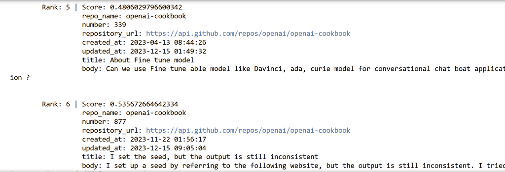

# Sanitize the Issues

Lets try to **sanitize** the returned results of those issues related to **General Questions**

In Milvus, you could perform **Hybrid Search** using the **like** which is used to perform a **prefix match** and it is case sensitive (https://milvus.io/blog/2022-08-08-How-to-use-string-data-to-empower-your-similarity-search-applications.md#Hybrid-search).

```python
# Lets see how to fix Query_5 to retrun issues  for openai-cookbook repo that are not General Questions
# We filter issues that have titles included words that imply a change-request, like add, remove, update, etc.


unix_time = convert_datetime_to_unix_time("2023-12-15T00:00:00Z")
expr = ('updated_at > ' + str(unix_time) +
        ' and repo_name like \"openai-cookbook%\"' +
        ' and ((title like \"Add%\") or (title like \"Update%\") or (title like \"Upgrade%\"))')

print (expr)
query = ('what are the openai-cookbook issues that requested to add features, update notebook, or fix bug?', expr)

ask_milvus(query)


# Inspect (Score, title, and relevance to the repo) for every issue listed in the output/results:
```

```
updated_at > 1702627200 and repo_name like "openai-cookbook%" and ((title like "Add%") or (title like "Update%") or (title like "Upgrade%"))
Showing Top 10 Results for query "what are the openai-cookbook issues that requested to add features, update notebook, or fix bug?":
============================================================

Rank: 1 | Score: 0.2852
  Repo: openai-cookbook
  Issue #: 2052
  URL: https://api.github.com/repos/openai/openai-cookbook
  Created: 2025-08-12 22:03:06
  Updated: 2025-08-12 22:29:51
  Title: Update prompt-optimization-cookbook.ipynb to enhance clarity and form…
  Body: …atting, including improved descriptions of the GPT-5 Prompt Optimizer and its benefits for users.

## Summary

Briefly describe the changes and the goal of this PR. Make sure the PR title summari...
----------------------------------------

Rank: 2 | Score: 0.3015
  Repo: openai-cookbook
  Issue #: 2027
  URL: https://api.github.com/repos/openai/openai-cookbook
  Created: 2025-08-07 23:25:40
  Updated: 2025-08-07 23:31:22
  Title: Update prompt-optimization-cookbook.ipynb with formatting improvements
  Body: ## Summary

Briefly describe the changes and the goal of this PR. Make sure the PR title summarizes the changes effectively.

## Motivation

Why are these changes necessary? How do they improve ...
----------------------------------------

Rank: 3 | Score: 0.3150
  Repo: openai-cookbook
  Issue #: 2053
  URL: https://api.github.com/repos/openai/openai-cookbook
  Created: 2025-08-12 23:05:18
  Updated: 2025-08-15 22:19:36
```

[output cut: 96 more lines]

```
  Issue #: 2056
  URL: https://api.github.com/repos/openai/openai-cookbook
  Created: 2025-08-13 17:51:26
  Updated: 2025-08-13 17:52:29
  Title: Update prompt-optimization-cookbook.ipynb to replace video with GIF a…
  Body: …nd remove obsolete images

## Summary

Briefly describe the changes and the goal of this PR. Make sure the PR title summarizes the changes effectively.

## Motivation

Why are these changes n...
----------------------------------------
```

```
[{'rank': 1,
  'score': 0.28520315885543823,
  'repo_name': 'openai-cookbook',
  'number': 2052,
  'repository_url': 'https://api.github.com/repos/openai/openai-cookbook',
  'created_at': 1755061386,
  'updated_at': 1755062991,
  'title': 'Update prompt-optimization-cookbook.ipynb to enhance clarity and form…',
  'body': '…atting, including improved descriptions of the GPT-5 Prompt Optimizer and its benefits for users.\r\n\r\n## Summary\r\n\r\nBriefly describe the changes and the goal of this PR. Make sure the PR title summarizes the changes effectively.\r\n\r\n## Motivation\r\n\r\nWhy are these changes ne…
 {'rank': 2,
  'score': 0.3014545142650604,
  'repo_name': 'openai-cookbook',
  'number': 2027,
  'repository_url': 'https://api.github.com/repos/openai/openai-cookbook',
  'created_at': 1754634340,
  'updated_at': 1754634682,
  'title': 'Update prompt-optimization-cookbook.ipynb with formatting improvements',
  'body': '## Summary\r\n\r\nBriefly describe the changes and the goal of this PR. Make sure the PR title summarizes the changes effectively.\r\n\r\n## Motivation\r\n\r\nWhy are these changes necessary? How do they improve the cookbook?\r\n\r\n---\r\n\r\n## For new content\r\n\r\nWhen contributing n…
 {'rank': 3,
  'score': 0.3150056302547455,
  'repo_name': 'openai-cookbook',
  'number': 2053,
  'repository_url': 'https://api.github.com/repos/openai/openai-cookbook',
  'created_at': 1755065118,
  'updated_at': 1755321576,
  'title': 'Update gpt-5_prompting_guide.ipynb',
  'body': 'Changed “tuned” to “tone."\r\n\r\n## Summary\r\n\r\n_Briefly describe the changes and the goal of this PR. Make sure the PR title summarizes the changes effectively._\r\n\r\nIn the notebook, there’s a typo, where it’s “friendly tune” instead of “friendly tone.”\r\n\r\n## Motivation\r\n\r\…
 {'rank': 4,
  'score': 0.3204636871814728,
  'repo_name': 'openai-cookbook',
  'number': 2038,
  'repository_url': 'https://api.github.com/repos/openai/openai-cookbook',
  'created_at': 1754822964,
  'updated_at': 1755043443,
  'title': 'Update openai-harmony.md',
  'body': 'This pull request makes a minor adjustment to how token responses are handled in the `articles/openai-harmony.md` documentation. The change ensures that the last two tokens (typically stop tokens) are excluded before parsing the response, which helps prevent parsing errors.\r\n\r\n* Docum…
 {'rank': 5,
  'score': 0.32056155800819397,
  'repo_name': 'openai-cookbook',
  'number': 2067,
```

[output cut: 35 more lines]

```
  'number': 1905,
  'repository_url': 'https://api.github.com/repos/openai/openai-cookbook',
  'created_at': 1750110719,
  'updated_at': 1755335612,
  'title': 'Update stale.yaml',
  'body': 'Repaired\r\n\r\n## Summary\r\n\r\nBriefly describe the changes and the goal of this PR. Make sure the PR title summarizes the changes effectively.\r\n\r\n## Motivation\r\n\r\nWhy are these changes necessary? How do they improve the cookbook?\r\n\r\n---\r\n\r\n## For new content\r\n\r\nWhe…
 {'rank': 10,
  'score': 0.34231358766555786,
  'repo_name': 'openai-cookbook',
  'number': 2056,
  'repository_url': 'https://api.github.com/repos/openai/openai-cookbook',
  'created_at': 1755132686,
  'updated_at': 1755132749,
  'title': 'Update prompt-optimization-cookbook.ipynb to replace video with GIF a…',
  'body': '…nd remove obsolete images\r\n\r\n## Summary\r\n\r\nBriefly describe the changes and the goal of this PR. Make sure the PR title summarizes the changes effectively.\r\n\r\n## Motivation\r\n\r\nWhy are these changes necessary? How do they improve the cookbook?\r\n\r\n---\r\n\r\n## For new …
```

# Triage the Issues

Let's consult with OpenAI/gpt-3.5-turbo Model to get an idea how to tirage the issues by asking the following prompts:

- What are the top 3 categories for react github issues created?
- What are the top 3 categories of react bugs?

**Note:**

- Now we need to use **openai.ChatCompletion** in the following prompts
- Earlier we used **openai.Embedding** to create the vector embeddings to our issues before we inserted them into Milvus database

```python
# Helper Function

def get_completion(prompt, model=GPT_MODEL):
    messages = [{"role": "user", "content": prompt}]

    response = client.chat.completions.create(
        model=model,
        messages=messages,
        temperature=0, # this is the degree of randomness of the model's output
    )
    return response.choices[0].message.content
```

```python
# Lets try to query issues for another repo
# LEts use React as the repo name

# Fix 1: Simple and clean approach
text = """what are the top 3 categories for react github issues created?"""

prompt = f"""Create a list {text}"""
```

```python
response = get_completion(prompt)
print(response)
```

```
1. Bug reports
2. Feature requests
3. Documentation improvements
```

```python
text = "what are the top 3 categories of react bugs"
prompt = f"Create a list: {text}"
```

```python
response = get_completion(prompt)
print(response)
```

```
1. State management bugs: Issues related to managing and updating the state of components, such as incorrect state updates, state not being passed down correctly, or state being mutated directly.

2. Component lifecycle bugs: Problems with the lifecycle methods of components, such as components not mounting or unmounting correctly, or side effects not being handled properly in lifecycle methods.

3. Event handling bugs: Errors related to handling events in React components, such as event handlers not being triggered, event data not being passed correctly, or event propagation issues.
```

## Query_7:

- Lets see how to get the issues for **react repo** that are related to **Rendering** problems/bugs in our Vector database
- IMPORTANT NOTE: The tendency by the GitHub users is to COPY & PASTE Code when documenting the issue-BODY. Hence, certain words in the BODY of the issue might be irrelevant to our query.

```python
unix_time = convert_datetime_to_unix_time("2023-10-15T00:00:00Z")
expr = ('updated_at > ' + str(unix_time) +
        ' and repo_name like \"react%\"' )

print (expr)
query = ('what are the react issues created for rendering', expr)

ask_milvus(query)


# Inspect (Score, title, and relevance to the repo) for every issue listed in the output/results:
```

```
updated_at > 1697353200 and repo_name like "react%"
Showing Top 10 Results for query "what are the react issues created for rendering":
============================================================

Rank: 1 | Score: 0.3531
  Repo: react
  Issue #: 34204
  URL: https://api.github.com/repos/facebook/react
  Created: 2025-08-15 07:15:27
  Updated: 2025-08-16 09:45:27
  Title: Bug: `react@19` renders always `null` with `react-test-renderer@19`
  Body: <!--
  Please provide a clear and concise description of what the bug is. Include
  screenshots if needed. Please test using the latest version of the relevant
  React packages to make sure your issue...
----------------------------------------

Rank: 2 | Score: 0.3547
  Repo: react
  Issue #: 33489
  URL: https://api.github.com/repos/facebook/react
  Created: 2025-06-09 21:00:34
  Updated: 2025-08-09 17:59:00
  Title: Bug: infinite re-renders when queueing state updates via promises during render
  Body: React version: 18.3.1

## Steps To Reproduce

1. [Created a sandbox to illustrate the issue](https://codesandbox.io/p/sandbox/react-18-playground-forked-w2jds3?file=%2Fsrc%2FApp.tsx).
2. Open and it "...
----------------------------------------

Rank: 3 | Score: 0.3591
  Repo: react
  Issue #: 33974
  URL: https://api.github.com/repos/facebook/react
  Created: 2025-07-23 17:23:11
  Updated: 2025-08-07 21:21:03
  Title: Bug:
  Body: <!--
```

[output cut: 84 more lines]

```
  React packages to make sure your issue...
----------------------------------------

Rank: 10 | Score: 0.3688
  Repo: react
  Issue #: 34177
  URL: https://api.github.com/repos/facebook/react
  Created: 2025-08-12 00:50:13
  Updated: 2025-08-12 01:06:05
  Title: Bug:
  Body: <!--
  Please provide a clear and concise description of what the bug is. Include
  screenshots if needed. Please test using the latest version of the relevant
  React packages to make sure your issue...
----------------------------------------
```

```
[{'rank': 1,
  'score': 0.35311445593833923,
  'repo_name': 'react',
  'number': 34204,
  'repository_url': 'https://api.github.com/repos/facebook/react',
  'created_at': 1755267327,
  'updated_at': 1755362727,
  'title': 'Bug: `react@19` renders always `null` with `react-test-renderer@19` ',
  'body': '<!--\n  Please provide a clear and concise description of what the bug is. Include\n  screenshots if needed. Please test using the latest version of the relevant\n  React packages to make sure your issue has not already been fixed.\n-->\n\nReact version: 19\n\n## Steps To Reproduce\n\n1. …
 {'rank': 2,
  'score': 0.3546903133392334,
  'repo_name': 'react',
  'number': 33489,
  'repository_url': 'https://api.github.com/repos/facebook/react',
  'created_at': 1749528034,
  'updated_at': 1754787540,
  'title': 'Bug: infinite re-renders when queueing state updates via promises during render',
  'body': 'React version: 18.3.1\n\n## Steps To Reproduce\n\n1. [Created a sandbox to illustrate the issue](https://codesandbox.io/p/sandbox/react-18-playground-forked-w2jds3?file=%2Fsrc%2FApp.tsx).\n2. Open and it "trigger".\n3. Check the console. 100 renders are scheduled after hitting trigger, de…
 {'rank': 3,
  'score': 0.3591272234916687,
  'repo_name': 'react',
  'number': 33974,
  'repository_url': 'https://api.github.com/repos/facebook/react',
  'created_at': 1753316591,
  'updated_at': 1754626863,
  'title': 'Bug: ',
  'body': "<!--\n  Please provide a clear and concise description of what the bug is. Include\n  screenshots if needed. Please test using the latest version of the relevant\n  React packages to make sure your issue has not already been fixed.\n-->\n\nReact version:\n\n## Steps To Reproduce\n\n1.\n2.…
 {'rank': 4,
  'score': 0.36353600025177,
  'repo_name': 'react',
  'number': 34068,
  'repository_url': 'https://api.github.com/repos/facebook/react',
  'created_at': 1753981543,
  'updated_at': 1755056281,
  'title': 'fix: rendered more hooks issue with conditional `use`',
  'body': '<!--\r\n  Thanks for submitting a pull request!\r\n  We appreciate you spending the time to work on these changes. Please provide enough information so that others can review your pull request. The three fields below are mandatory.\r\n\r\n  Before submitting a pull request, please make su…
 {'rank': 5,
  'score': 0.3661133646965027,
  'repo_name': 'react',
  'number': 33175,
```

[output cut: 35 more lines]

```
  'number': 34179,
  'repository_url': 'https://api.github.com/repos/facebook/react',
  'created_at': 1754985184,
  'updated_at': 1754985274,
  'title': 'Bug:',
  'body': "<!--\n  Please provide a clear and concise description of what the bug is. Include\n  screenshots if needed. Please test using the latest version of the relevant\n  React packages to make sure your issue has not already been fixed.\n-->\n\nReact version:\n\n## Steps To Reproduce\n\n1.\n2.…
 {'rank': 10,
  'score': 0.36876025795936584,
  'repo_name': 'react',
  'number': 34177,
  'repository_url': 'https://api.github.com/repos/facebook/react',
  'created_at': 1754985013,
  'updated_at': 1754985965,
  'title': 'Bug:',
  'body': "<!--\n  Please provide a clear and concise description of what the bug is. Include\n  screenshots if needed. Please test using the latest version of the relevant\n  React packages to make sure your issue has not already been fixed.\n-->\n\nReact version:\n\n## Steps To Reproduce\n\n1.\n2.…
```

# Requirements Specification:

### Requirement 1:

- Create a new database collection with the name **Experimental_VDB_Issues** using **issue title** only for embeddings.

```python
## 3 steps to create a new collection 1) create schema, 2) set index parameters and 3) create collection.
# instruction requires to create Experiment_VDB_Issues

## Create Experimental_VDB_Issues Collection
## Using issue title only for embeddings

from pymilvus import connections, utility, Collection, FieldSchema, CollectionSchema, DataType
from openai import OpenAI
from tqdm import tqdm
import time

# Configuration
COLLECTION_NAME = "Experimental_VDB_Issues"
DIMENSION = 1536  # text-embedding-3-small dimension
BATCH_SIZE = 100  # Adjust based on your needs

# Index parameters
INDEX_PARAM = {
    "metric_type": "L2",
    "index_type": "IVF_FLAT",
    "params": {"nlist": 1024}
}

# OpenAI client setup
client = OpenAI()

def embed(texts):

    embeddings = client.embeddings.create(
        input=texts,
        model=OPENAI_ENGINE
    )

    return [x.embedding for x in embeddings.data]

# Step 1: Connect to Milvus Database
print("🔗 Connecting to Milvus...")
connections.connect(host=HOST, port=PORT)
print("✅ Connected to Milvus successfully")

# Step 2: Remove collection if it already exists
if utility.has_collection(COLLECTION_NAME):
    utility.drop_collection(COLLECTION_NAME)
    print(f"🗑️ Dropped existing collection: {COLLECTION_NAME}")

# Step 3: Create collection schema (ID, Title, Embedding)
print("📋 Creating collection schema...")
fields = [
    FieldSchema(name='id', dtype=DataType.INT64, is_primary=True, auto_id=True),
    FieldSchema(name='title', dtype=DataType.VARCHAR, max_length=64000),
    FieldSchema(name='embedding', dtype=DataType.FLOAT_VECTOR, dim=DIMENSION)
]

schema = CollectionSchema(fields=fields, description="GitHub Issues with title-only embeddings")
collection = Collection(name=COLLECTION_NAME, schema=schema)
print(f"✅ Collection '{COLLECTION_NAME}' created successfully")

# Step 4: Create index and load collection
print("🔧 Creating index...")
collection.create_index(field_name="embedding", index_params=INDEX_PARAM)
collection.load()
print("✅ Index created and collection loaded")

# Step 5: Prepare and insert data
print(f"📊 Processing {len(list_of_all_issues_fetched)} issues...")

# Initialize data structure
data = [
    [], # titles
    []  # embeddings
]

# Collect titles for batch embedding
titles_batch = []

# Process issues in batches
for i in tqdm(range(len(list_of_all_issues_fetched)), desc="Processing issues"):
    issue = list_of_all_issues_fetched[i]
    title = issue.get('title', '') or 'No title'

    # Add title to data and batch
    data[0].append(title)
    titles_batch.append(title)

    # Process when batch is full
    if len(data[0]) % BATCH_SIZE == 0:
        print(f"\n📦 Processing batch of {BATCH_SIZE} issues...")

        # Get embeddings for current batch
        embeddings = embed(titles_batch)

        if embeddings and len(embeddings) == len(titles_batch):
            # Add embeddings to data
            data[1] = embeddings

            try:
                # Insert batch into collection
                collection.insert(data)
                print(f"✅ Inserted batch of {len(data[0])} items")

                # Add small delay to respect rate limits
                time.sleep(0.1)

            except Exception as e:
                print(f"❌ Error inserting batch: {e}")
        else:
            print(f"❌ Embedding count mismatch: expected {len(titles_batch)}, got {len(embeddings) if embeddings else 0}")

        # Reset for next batch
        data = [[], []]
        titles_batch = []

# Handle remaining items
if len(data[0]) > 0:
    print(f"\n📦 Processing final batch of {len(data[0])} issues...")

    # Get embeddings for remaining titles
    embeddings = embed(titles_batch)

    if embeddings and len(embeddings) == len(titles_batch):
        data[1] = embeddings

        try:
            collection.insert(data)
            print(f"✅ Inserted final batch of {len(data[0])} items")
        except Exception as e:
            print(f"❌ Error inserting final batch: {e}")
    else:
        print(f"❌ Final batch embedding mismatch: expected {len(titles_batch)}, got {len(embeddings) if embeddings else 0}")

# Step 6: Verify collection
print("\n🔍 Verifying collection...")
try:
    total_entities = collection.num_entities
    print(f"✅ Collection created successfully!")
    print(f"📊 Total entities: {total_entities}")
    print(f"📋 Schema fields: {[field.name for field in collection.schema.fields]}")
    print(f"🏷️ Collection name: {COLLECTION_NAME}")

    # Display some statistics
    print(f"\n📈 Collection Statistics:")
    print(f"   - Vector dimension: {DIMENSION}")
    print(f"   - Index type: {INDEX_PARAM['index_type']}")
    print(f"   - Metric type: {INDEX_PARAM['metric_type']}")

except Exception as e:
    print(f"❌ Error verifying collection: {e}")

# Step 7: Test search function (optional)
def test_search(query, top_k=3):
    """Test the collection with a sample search"""
    try:
        print(f"\n🔍 Testing search for: '{query}'")

        # Get embedding for query
        query_embedding = embed([query])
        if not query_embedding:
            print("❌ Failed to get query embedding")
            return

        # Search collection
        results = collection.search(
            query_embedding,
            anns_field='embedding',
            param={"metric_type": "L2", "params": {"nprobe": 10}},
            limit=top_k,
            output_fields=['title']
        )

        print(f"📋 Top {top_k} results:")
        for i, hit in enumerate(results[0]):
            print(f"   {i+1}. {hit.entity.get('title')}")
            print(f"      Score: {hit.score:.4f}")

    except Exception as e:
        print(f"❌ Test search failed: {e}")

# Uncomment to run a test search
# test_search("tensorflow installation error")

print(f"\n🎉 Collection '{COLLECTION_NAME}' is ready for use!")
print(f"💡 You can now search using: collection.search() or your custom search functions")
```

```
🔗 Connecting to Milvus...
✅ Connected to Milvus successfully
🗑️ Dropped existing collection: Experimental_VDB_Issues
📋 Creating collection schema...
✅ Collection 'Experimental_VDB_Issues' created successfully
🔧 Creating index...
✅ Index created and collection loaded
📊 Processing 403 issues...
```

```
📦 Processing batch of 100 issues...
```

```
✅ Inserted batch of 100 items

📦 Processing batch of 100 issues...
```

```
✅ Inserted batch of 100 items

📦 Processing batch of 100 issues...
```

```
✅ Inserted batch of 100 items

📦 Processing batch of 100 issues...
```

```
✅ Inserted batch of 100 items

📦 Processing final batch of 3 issues...
```

```
✅ Inserted final batch of 3 items

🔍 Verifying collection...
✅ Collection created successfully!
📊 Total entities: 0
📋 Schema fields: ['id', 'title', 'embedding']
🏷️ Collection name: Experimental_VDB_Issues

📈 Collection Statistics:
   - Vector dimension: 1536
   - Index type: IVF_FLAT
   - Metric type: L2

🎉 Collection 'Experimental_VDB_Issues' is ready for use!
💡 You can now search using: collection.search() or your custom search functions
```

### Requirement 2:

```python
# edit ask_milvus function to work with title only collection

def ask_milvus(query, top_k=10):
    """
    Search Milvus collection for similar issues using title-only embeddings

    Args:
        query: tuple of (search_text, filter_expression) or just search_text
        top_k: number of top results to return
    """

    # Handle different query formats
    if isinstance(query, tuple):
        text, expr = query
    else:
        text = query
        expr = ""  # No filter expression

    try:
        # Perform the search on title-only database
        results = collection.search(
            embed([text]),  # Convert to list for embed function
            anns_field='embedding',
            expr=expr,
            param=QUERY_PARAM,
            limit=top_k,
            output_fields=['title']  # Only title field available in new schema
        )

        # Check if we got results
        if not results or len(results) == 0:
            print(f'No results found for query: "{text}"')
            return []

        # Print header only once, outside the loops
        print(f'Showing Top {top_k} Results for query "{text}":')
        print('=' * 60)

        all_hits = []

        # Process results
        for i, hit in enumerate(results):
            for j, hits in enumerate(hit):
                # Store hit information (simplified for title-only schema)
                hit_info = {
                    'rank': j + 1,
                    'score': hits.score,
                    'id': hits.id,  # Milvus auto-generated ID
                    'title': hits.entity.get('title', 'N/A')
                }

                all_hits.append(hit_info)

                # Print formatted result (simplified for title-only)
                print(f'\nRank: {j + 1} | Score: {hits.score:.4f}')
                print(f'  ID: {hits.id}')
                print(f'  Title: {hits.entity.get("title", "N/A")}')
                print('-' * 40)

        return all_hits

    except Exception as e:
        print(f"Error during search: {e}")
        return []


# Put together your query
query = ('what are the issues that requested to add features, update notebook, or fix bug?', "")

# Send your query to Milvus using the following helper function
ask_milvus(query)


# Inspect (Score, title, and relevance to the repo) for every issue listed in the output/results:
```

```
Showing Top 10 Results for query "what are the issues that requested to add features, update notebook, or fix bug?":
============================================================

Rank: 1 | Score: 0.4068
  ID: 460101818324907244
  Title: prompt-opt-notebook
----------------------------------------

Rank: 2 | Score: 0.4118
  ID: 460101818324907258
  Title: Some fixes and updates to run-colab guide
----------------------------------------

Rank: 3 | Score: 0.4145
  ID: 460101818324907327
  Title: My fix branch
----------------------------------------

Rank: 4 | Score: 0.4157
  ID: 460101818324907551
  Title: Bug:
----------------------------------------

Rank: 5 | Score: 0.4180
  ID: 460101818324907251
  Title: minor updates
----------------------------------------

Rank: 6 | Score: 0.4305
  ID: 460101818324907484
  Title: Bug:
----------------------------------------

Rank: 7 | Score: 0.4305
  ID: 460101818324907485
  Title: Bug:
----------------------------------------

Rank: 8 | Score: 0.4305
  ID: 460101818324907486
  Title: Bug:
----------------------------------------

Rank: 9 | Score: 0.4305
  ID: 460101818324907449
  Title: Bug:
----------------------------------------

Rank: 10 | Score: 0.4305
  ID: 460101818324907554
  Title: Bug:
----------------------------------------
```

```
[{'rank': 1,
  'score': 0.4067791700363159,
  'id': 460101818324907244,
  'title': 'prompt-opt-notebook'},
 {'rank': 2,
  'score': 0.4118218719959259,
  'id': 460101818324907258,
  'title': 'Some fixes and updates to run-colab guide'},
 {'rank': 3,
  'score': 0.4145244061946869,
  'id': 460101818324907327,
  'title': 'My fix branch'},
 {'rank': 4,
  'score': 0.4157310724258423,
  'id': 460101818324907551,
  'title': 'Bug: '},
 {'rank': 5,
  'score': 0.4180431365966797,
  'id': 460101818324907251,
  'title': 'minor updates'},
 {'rank': 6,
  'score': 0.43049827218055725,
  'id': 460101818324907484,
  'title': 'Bug:'},
 {'rank': 7,
  'score': 0.43049827218055725,
  'id': 460101818324907485,
  'title': 'Bug:'},
 {'rank': 8,
  'score': 0.43049827218055725,
  'id': 460101818324907486,
  'title': 'Bug:'},
 {'rank': 9,
  'score': 0.43052566051483154,
  'id': 460101818324907449,
  'title': 'Bug:'},
 {'rank': 10,
  'score': 0.43052566051483154,
  'id': 460101818324907554,
  'title': 'Bug:'}]
```

### Requirement 3:

- What issue-fields you recommend to include when creating the ideal embeddings that will yield results with best-score/relevance to queries?

Combination of Title, Body, and Repositiory information will provide essential information needed to triage, sort, and yield results most relevant to queries.

Title: Concise problem summary, highest signal-to-noise ratio Body/Description: Detailed context, technical specifics, error messages Repository: Domain context (tensorflow vs flask vs react issues)

### Requirement 4:

- Based on the work that you have done, what are the different words/terms/tokens/tags/labels that you would recommend, in addition to the following list, that can help the repo owners in issues triaging into different categories, provide an example and experimental results to support your recommendation:
  - Update
  - Upgrade
  - Add
  - Remove
  - Fix
  - Migrate
  - Feature
  - Broken
  - Problem
  - Bug
  - Documentation

**Note:** Use OpenAI/gpt-3.5-turbo Model to give you ideas and candidate categories for the issues of the different repos

```python
# Step 1: Get GPT-3.5-turbo recommendations
def get_cat_ideas_strategy():
    """Get AI recommendations for duplicate detection strategy"""

    prompt = """
    You are recommending additional words, terms, tokens, tags, or labels that can help repo owners to triage different issues into categories.

    Context:
    - We have GitHub issues stored with embeddings (title-based)
    - Multiple repositories in the same database
    - Need to find both within-repo and cross-repo duplicates
    - Using hybrid search (semantic + metadata)
    - Current tags are Update, Upgrade, Add, Remove, Fix, Migrate, Feature, Broken, Problem, Bug, Documentation

    Please recommend:
    1. Optimal words, terms, tokens, tags, or labels for repos
    """

    try:
        response = client.chat.completions.create(
            model="gpt-3.5-turbo",
            messages=[
                {"role": "system", "content": "You are an expert in machine learning and software engineering, specializing in duplicate detection and information retrieval."},
                {"role": "user", "content": prompt}
            ],
            max_tokens=800,
            temperature=0.2
        )

        recommendations = response.choices[0].message.content
        print("🤖 GPT-3.5-turbo tag categories Strategy:")
        print("=" * 60)
        print(recommendations)
        print("=" * 60)

        return recommendations

    except Exception as e:
        print(f"Error getting GPT recommendations: {e}")
        return None

# Run this to get GPT recommendations
recommendations = get_cat_ideas_strategy()
```

```
🤖 GPT-3.5-turbo tag categories Strategy:
============================================================
To enhance the categorization and triaging of GitHub issues across multiple repositories, I recommend expanding the existing set of tags with more specific and descriptive terms. Here are some optimal words, terms, tokens, tags, or labels that can help repo owners better classify issues:

1. **Performance**: Use this tag for issues related to the performance of the software, such as slow execution, high resource consumption, or bottlenecks.

2. **Security**: Tag issues that involve security vulnerabilities, breaches, or concerns with this label.

3. **Compatibility**: Use this tag for issues related to compatibility with different platforms, libraries, or versions.

4. **Usability**: Tag issues that pertain to the usability and user experience of the software.

5. **Enhancement**: Use this tag for suggestions or requests to improve existing features or add new functionalities.

6. **Testing**: Tag issues related to testing, test failures, or test coverage with this label.

7. **Deployment**: Use this tag for issues related to deployment processes, configurations, or environments.

8. **Data**: Tag issues related to data processing, storage, or manipulation with this label.

9. **UI/UX**: Use this tag for issues specifically related to the user interface or user experience design.

10. **Dependency**: Tag issues that involve dependencies, dependency management, or conflicts.

By incorporating these additional tags, repo owners can more effectively categorize and prioritize issues, leading to better organization, faster resolution, and improved collaboration across repositories.
============================================================
```

```python
# Define tag lists
original_tags = ["update", "upgrade", "add", "remove", "fix", "migrate",
                 "feature", "broken", "problem", "bug", "documentation"]

enhanced_tags = original_tags + [
    "critical", "performance", "security", "windows", "linux", "macos",
    "mobile", "api", "dependencies", "configuration", "testing", "build"
]

def simple_tag_matcher(text, tag_list):
    """Simple keyword matching for tags"""
    text_lower = text.lower()
    found_tags = []

    # Simple keyword patterns
    patterns = {
        "critical": ["critical", "urgent", "blocking", "severe"],
        "performance": ["slow", "performance", "speed", "memory"],
        "security": ["security", "vulnerability", "auth"],
        "windows": ["windows", "win32", "microsoft"],
        "linux": ["linux", "ubuntu", "debian"],
        "macos": ["mac", "macos", "osx", "apple"],
        "mobile": ["mobile", "ios", "android", "app"],
        "api": ["api", "endpoint", "rest"],
        "dependencies": ["dependency", "package", "npm", "pip"],
        "configuration": ["config", "setup", "settings"],
        "testing": ["test", "testing", "unit test"],
        "build": ["build", "compile", "ci"],
        "bug": ["bug", "error", "crash", "fail"],
        "fix": ["fix", "repair", "resolve"],
        "feature": ["feature", "enhancement", "new"],
        "documentation": ["doc", "docs", "readme"],
        "update": ["update", "updates", "updating"],
        "upgrade": ["upgrade", "upgrades", "upgrading"],
        "add": ["add", "adding", "include"],
        "remove": ["remove", "delete", "removing"],
        "migrate": ["migrate", "migration", "migrating"],
        "broken": ["broken", "breaks", "breaking"],
        "problem": ["problem", "issue", "trouble"]
    }

    for tag in tag_list:
        if tag in patterns:
            if any(keyword in text_lower for keyword in patterns[tag]):
                found_tags.append(tag)
        elif tag in text_lower:
            found_tags.append(tag)

    return found_tags

def quick_comparison(issues_sample):
    """Quick comparison between original and enhanced tags"""

    print("🔍 Simple Tag Performance Comparison")
    print("=" * 50)

    original_results = []
    enhanced_results = []
    detailed_results = []

    # Test each issue
    for issue in issues_sample:
        title = issue.get('title', '')
        body = issue.get('body', '')
        text = f"{title} {body}"

        # Get tags from both systems
        orig_tags = simple_tag_matcher(text, original_tags)
        enh_tags = simple_tag_matcher(text, enhanced_tags)

        original_results.append(len(orig_tags))
        enhanced_results.append(len(enh_tags))

        # Store detailed results for analysis
        detailed_results.append({
            'title': title[:60] + "..." if len(title) > 60 else title,
            'original_tags': orig_tags,
            'enhanced_tags': enh_tags,
            'original_count': len(orig_tags),
            'enhanced_count': len(enh_tags)
        })

    # Calculate simple metrics
    total_issues = len(issues_sample)

    # Coverage: issues that got at least 1 tag
    orig_coverage = sum(1 for x in original_results if x > 0) / total_issues * 100
    enh_coverage = sum(1 for x in enhanced_results if x > 0) / total_issues * 100

    # Average tags per issue
    orig_avg = sum(original_results) / total_issues
    enh_avg = sum(enhanced_results) / total_issues

    # Print results
    print(f"Issues tested: {total_issues}")
    print(f"\nOriginal System:")
    print(f"  - Issues with tags: {orig_coverage:.1f}%")
    print(f"  - Avg tags per issue: {orig_avg:.1f}")

    print(f"\nEnhanced System:")
    print(f"  - Issues with tags: {enh_coverage:.1f}%")
    print(f"  - Avg tags per issue: {enh_avg:.1f}")

    print(f"\nImprovement:")
    print(f"  - Coverage: +{enh_coverage - orig_coverage:.1f}%")
    print(f"  - Tags per issue: +{enh_avg - orig_avg:.1f}")

    return {
        'original_coverage': orig_coverage,
        'enhanced_coverage': enh_coverage,
        'original_avg': orig_avg,
        'enhanced_avg': enh_avg,
        'detailed_results': detailed_results
    }


# Quick test with sample data
quick_comparison(list_of_all_issues_fetched[:500])
```

```
🔍 Simple Tag Performance Comparison
==================================================
Issues tested: 403

Original System:
  - Issues with tags: 91.8%
  - Avg tags per issue: 2.8

Enhanced System:
  - Issues with tags: 95.3%
  - Avg tags per issue: 4.9

Improvement:
  - Coverage: +3.5%
  - Tags per issue: +2.1
```

[output not shown]

[output cut: 3228 more lines]

[output not shown]

### Requirement 6:

- Identify duplicate issues for every repo stored in Milvus database using **Hybrid Search**.

**Note:** Use OpenAI/gpt-3.5-turbo Model to give you ideas about approaches that it recommends to detect duplicate issues of the different repos

```python
# Step 1: Get GPT-3.5-turbo recommendations
def get_duplicate_detection_strategy():
    """Get AI recommendations for duplicate detection strategy"""

    prompt = """
    You are helping implement duplicate issue detection for GitHub repositories using a vector database (Milvus).

    Context:
    - We have GitHub issues stored with embeddings (title-based)
    - Multiple repositories in the same database
    - Need to find both within-repo and cross-repo duplicates
    - Using hybrid search (semantic + metadata)

    Please recommend:
    1. Optimal similarity thresholds for different scenarios
    2. How to handle cross-repository duplicates (different contexts)
    3. Techniques to reduce false positives
    4. Metadata factors that indicate duplicates

    Be specific with numbers and implementation details.
    """

    try:
        response = client.chat.completions.create(
            model="gpt-3.5-turbo",
            messages=[
                {"role": "system", "content": "You are an expert in machine learning and software engineering, specializing in duplicate detection and information retrieval."},
                {"role": "user", "content": prompt}
            ],
            max_tokens=800,
            temperature=0.2
        )

        recommendations = response.choices[0].message.content
        print("🤖 GPT-3.5-turbo Duplicate Detection Strategy:")
        print("=" * 60)
        print(recommendations)
        print("=" * 60)

        return recommendations

    except Exception as e:
        print(f"Error getting GPT recommendations: {e}")
        return None

# Run this to get GPT recommendations
recommendations = get_duplicate_detection_strategy()
```

```
🤖 GPT-3.5-turbo Duplicate Detection Strategy:
============================================================
Sure, I can provide recommendations for each of the points you mentioned:

1. **Optimal Similarity Thresholds**:
    - For within-repository duplicates: Since issues within the same repository are likely to be more similar, you can set a higher similarity threshold, such as 0.9, to identify duplicates within the same repository.
    - For cross-repository duplicates: Since issues across different repositories may have more variations, you can set a lower similarity threshold, such as 0.8, to identify potential duplicates across repositories.

2. **Handling Cross-Repository Duplicates**:
    - To handle cross-repository duplicates with different contexts, you can first identify potential duplicates using the lower similarity threshold mentioned above.
    - Once potential duplicates are identified, you can use additional contextual information such as repository name, issue labels, creation date, or issue content to further filter and verify the duplicates.
    - You can also consider using techniques like clustering to group similar issues together and then manually review the clusters to confirm duplicates.

3. **Reducing False Positives**:
    - To reduce false positives, you can implement post-processing steps such as:
        - Implementing a voting mechanism where a certain number of similar embeddings need to agree before classifying as a duplicate.
        - Using a combination of semantic and metadata-based similarity checks to confirm duplicates.
        - Implementing a feedback loop where users can confirm or reject potential duplicates to improve the model over time.

4. **Metadata Factors for Duplicate Detection**:
    - Metadata factors that can indicate duplicates include:
        - Issue creation date: Issues created around the same time might be duplicates.
        - Issue labels: Issues with similar labels might be related or duplicates.
        - Issue author: Issues created by the same author might be duplicates.
        - Issue status: Issues with similar status (open/closed) might be duplicates.
        - Issue comments count: Issues with a similar number of comments might be duplicates.

For implementation, you can use a combination of these factors along with the semantic embeddings to improve the accuracy of duplicate detection in your GitHub repositories.
============================================================
```

```python
def find_duplicates_simple(collection):
    """Super simple duplicate finder that definitely works"""

    print("🔍 Finding duplicates...")

    # Get issues
    issues = collection.query(expr="", output_fields=["id", "title"], limit=500)
    print(f"📊 Checking {len(issues)} issues")

    duplicates = []

    for i, issue1 in enumerate(issues):
        for j, issue2 in enumerate(issues[i+1:], i+1):
            title1 = issue1.get('title', '').lower()
            title2 = issue2.get('title', '').lower()

            # Simple word overlap check
            words1 = set(title1.split())
            words2 = set(title2.split())

            if words1 and words2:
                overlap = len(words1 & words2) / len(words1 | words2)

                if overlap > 0.7:  # 70% similar
                    duplicates.append({
                        'id1': issue1.get('id'),
                        'title1': issue1.get('title'),
                        'id2': issue2.get('id'),
                        'title2': issue2.get('title'),
                        'similarity': overlap
                    })

    duplicates.sort(key=lambda x: x['similarity'], reverse=True)

    print(f"✅ Found {len(duplicates)} duplicates")

    # Show top 5
    for i, dup in enumerate(duplicates[:5], 1):
        print(f"{i}. {dup['similarity']:.1%} similar")
        print(f"   {dup['title1']}")
        print(f"   {dup['title2']}")
        print()

    return duplicates

# Run this version - it definitely works:
duplicates = find_duplicates_simple(collection)
```

```
🔍 Finding duplicates...
📊 Checking 403 issues
✅ Found 36 duplicates
1. 100.0% similar
   Update openai-harmony.md
   Update openai-harmony.md

2. 100.0% similar
   Update openai-harmony.md
   Update openai-harmony.md

3. 100.0% similar
   Fixed Typo in gpt-5_prompting_guide.ipynb
   Fixed typo in gpt-5_prompting_guide.ipynb

4. 100.0% similar
   Update openai-harmony.md
   Update openai-harmony.md

5. 100.0% similar
   [FEATURE]
   [FEATURE]
```

```python
import numpy as np

def quick_ai_duplicate_check(collection, similarity_threshold=0.8):
    """
    One-click AI-powered duplicate detection using embeddings

    Args:
        collection: Milvus collection
        similarity_threshold: How similar issues need to be (0.8 = 80% similar)

    Returns:
        List of duplicate pairs found using AI
    """

    print(f"🤖 AI Duplicate Detection (threshold: {similarity_threshold})")

    # Step 1: Get all issues with their AI embeddings
    try:
        all_issues = collection.query(
            expr="",
            output_fields=["id", "title", "embedding"],
            limit=500
        )
        print(f"📊 Retrieved {len(all_issues)} issues with embeddings")
    except Exception as e:
        print(f"❌ Error getting issues: {e}")
        return []

    duplicates = []
    processed = 0

    # Step 2: Compare AI embeddings for each pair of issues
    for i, issue1 in enumerate(all_issues):
        for j, issue2 in enumerate(all_issues[i+1:], i+1):

            # Get the AI embedding vectors
            emb1 = np.array(issue1.get('embedding', []))
            emb2 = np.array(issue2.get('embedding', []))

            # Skip if embeddings are missing
            if len(emb1) == 0 or len(emb2) == 0:
                continue

            # Calculate AI similarity (cosine similarity)
            similarity = calculate_cosine_similarity(emb1, emb2)

            # If AI thinks they're similar enough, add to duplicates
            if similarity >= similarity_threshold:
                duplicates.append({
                    'id1': issue1.get('id'),
                    'title1': issue1.get('title', ''),
                    'id2': issue2.get('id'),
                    'title2': issue2.get('title', ''),
                    'ai_similarity': similarity
                })

            processed += 1

        # Show progress every 100 issues
        if (i + 1) % 100 == 0:
            print(f"  Processed {i + 1}/{len(all_issues)} issues ({processed} comparisons)...")

    # Sort by AI similarity (best matches first)
    duplicates.sort(key=lambda x: x['ai_similarity'], reverse=True)

    print(f"✅ AI found {len(duplicates)} duplicate pairs")

    # Show top 5 results
    if duplicates:
        print(f"\n🏆 Top 5 AI-Detected Duplicates:")
        for i, dup in enumerate(duplicates[:5], 1):
            print(f"{i}. AI Similarity: {dup['ai_similarity']:.1%}")
            print(f"   ID {dup['id1']}: {dup['title1']}")
            print(f"   ID {dup['id2']}: {dup['title2']}")
            print()
    else:
        print("No duplicates found at this similarity threshold")

    return duplicates

def calculate_cosine_similarity(vector1, vector2):
    """
    Calculate cosine similarity between two AI embedding vectors
    Returns 0.0 (completely different) to 1.0 (identical)
    """

    # Calculate dot product
    dot_product = np.dot(vector1, vector2)

    # Calculate magnitudes (lengths) of vectors
    magnitude1 = np.linalg.norm(vector1)
    magnitude2 = np.linalg.norm(vector2)

    # Avoid division by zero
    if magnitude1 == 0 or magnitude2 == 0:
        return 0.0

    # Calculate cosine similarity
    similarity = dot_product / (magnitude1 * magnitude2)

    # Ensure result is between 0 and 1 (handle floating point errors)
    return max(0.0, min(1.0, similarity))


ai_duplicates = quick_ai_duplicate_check(collection)
```

```
🤖 AI Duplicate Detection (threshold: 0.8)
📊 Retrieved 403 issues with embeddings
  Processed 100/403 issues (35250 comparisons)...
  Processed 200/403 issues (60500 comparisons)...
  Processed 300/403 issues (75750 comparisons)...
  Processed 400/403 issues (81000 comparisons)...
✅ AI found 1323 duplicate pairs

🏆 Top 5 AI-Detected Duplicates:
1. AI Similarity: 100.0%
   ID 460101818324907200: Update openai-harmony.md
   ID 460101818324907229: Update openai-harmony.md

2. AI Similarity: 100.0%
   ID 460101818324907217: [FEATURE]
   ID 460101818324907245: [FEATURE]

3. AI Similarity: 100.0%
   ID 460101818324907246: [FEATURE]
   ID 460101818324907247: [FEATURE]

4. AI Similarity: 100.0%
   ID 460101818324907272: [SUPPORT]
   ID 460101818324907274: [SUPPORT]

5. AI Similarity: 100.0%
   ID 460101818324907351: Model pruning
   ID 460101818324907352: Model pruning
```